# STA 141A HW2

Zihan Mo 914998952

April 29, 2018

Q1 Justified by code in the appendix

Q2 The timespan of the housing sales cover from 2003-04-27 to 2006-06-04; The timespan of the construction year of houses cover from 1885 to 2005.

Q3

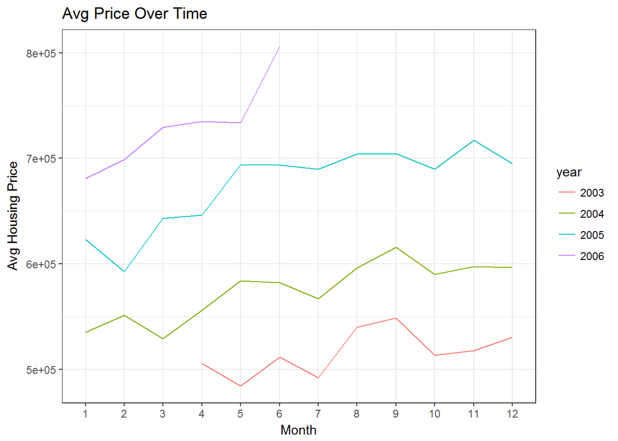

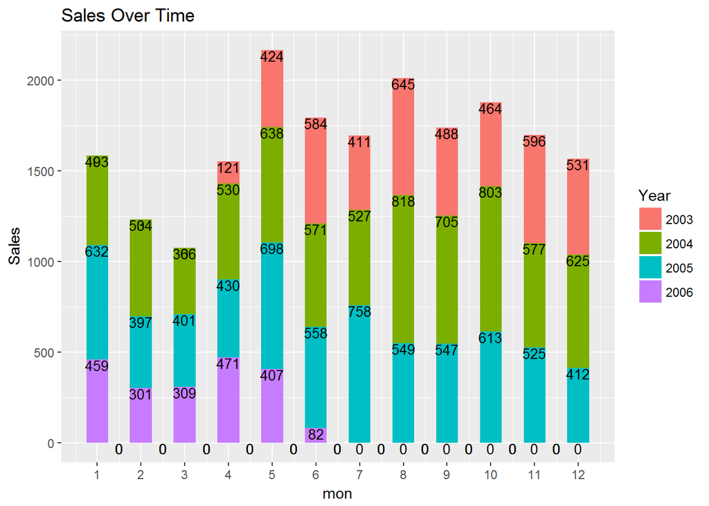

Q4

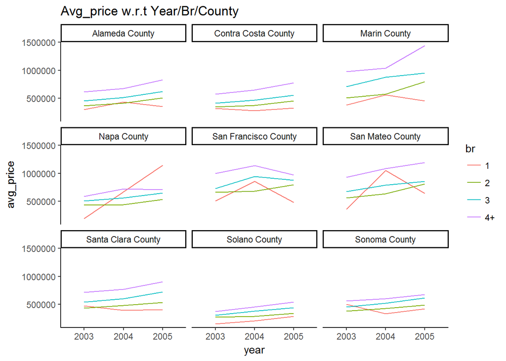

Q5

Only Vallejo city has sales in more than one county, which are Napa County and Solano County.

Q6

After taking out extreme outliers, like price equals zero and the building size larger than 10000, we have plots. Based on the plots below, the linear regression model seems provide a good fit to the data. But the QQ-plot and the residuals plot imply the nomality assumption isn’t met and the variance of residual is not constant.

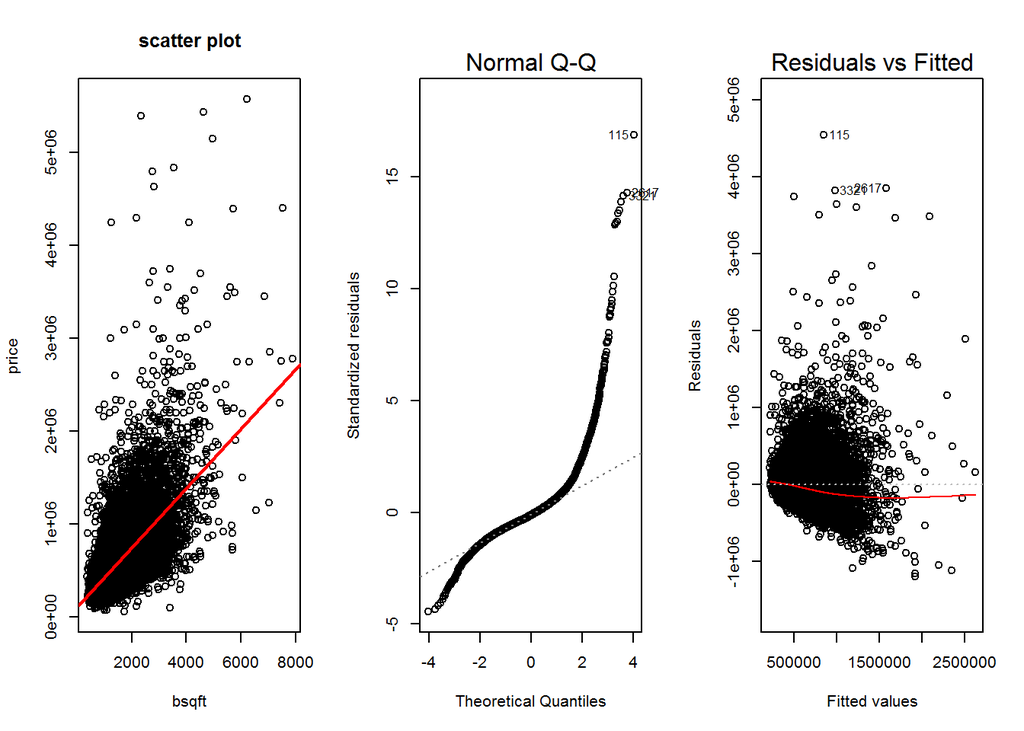

Based on the QQ-plot below, after BoxCox transformation, the QQ-plot roughly follows a straight line.

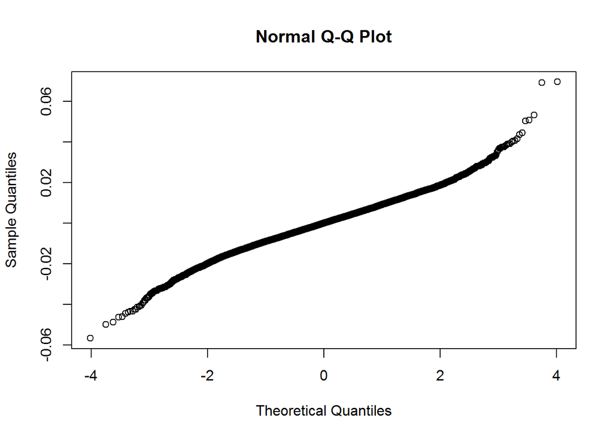

Q7

```r
model3<-lm(data$price~data$bsqft+data$lsqft)
model3_est<-coef(summary(model3))[,1]
model3_se<-coef(summary(model3))[,2]
t_star<-(model3_est[2]-model3_est[3])/(model3_se[2])
critical_val<-qt(0.99,19997)
t_star>=critical_val
```

```
## data$bsqft
##       TRUE
```

Q8

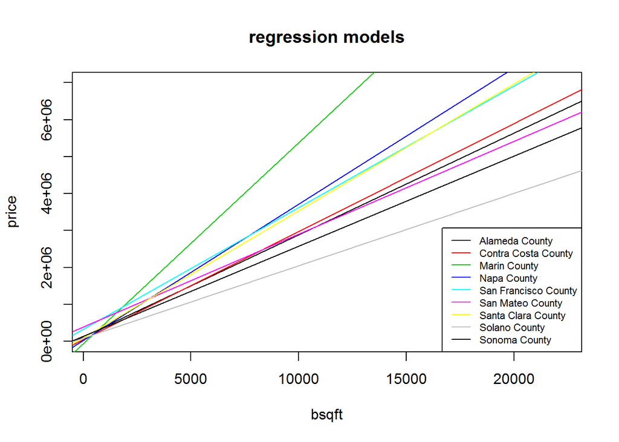

It’s obviouse that the simple regression lines with respect to different county are not parallel. Therefore, we can conclude the regression lines depend on county.

Q9

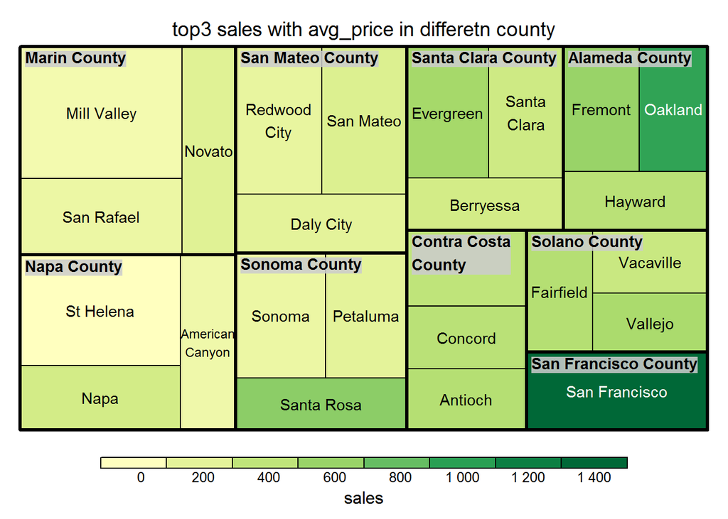

Q10

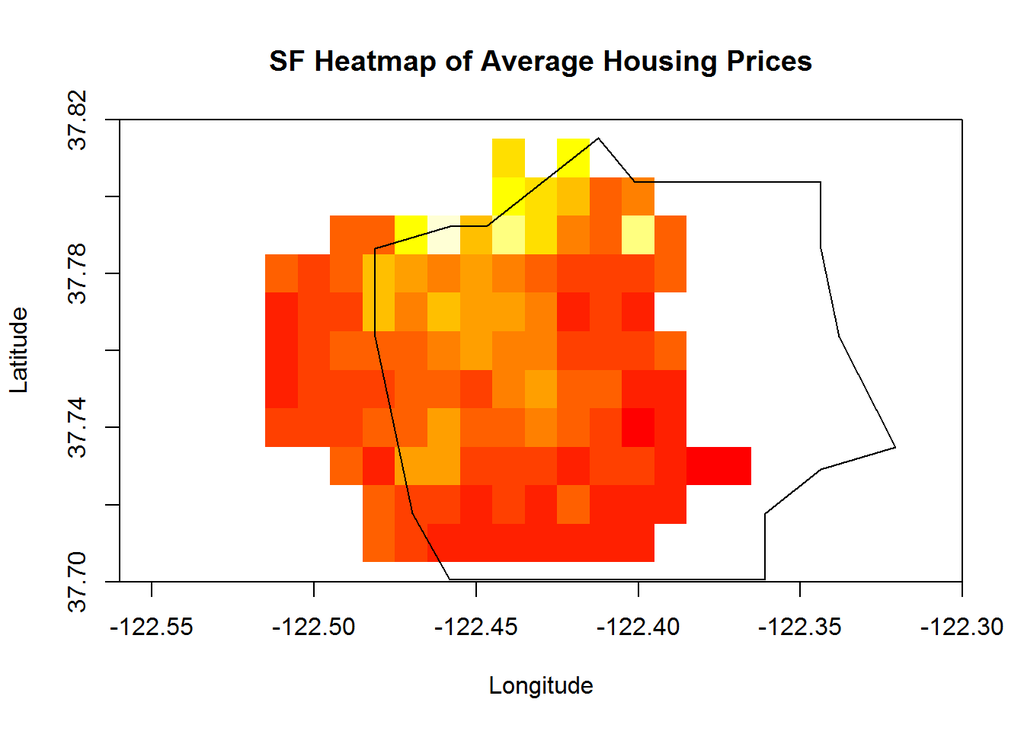

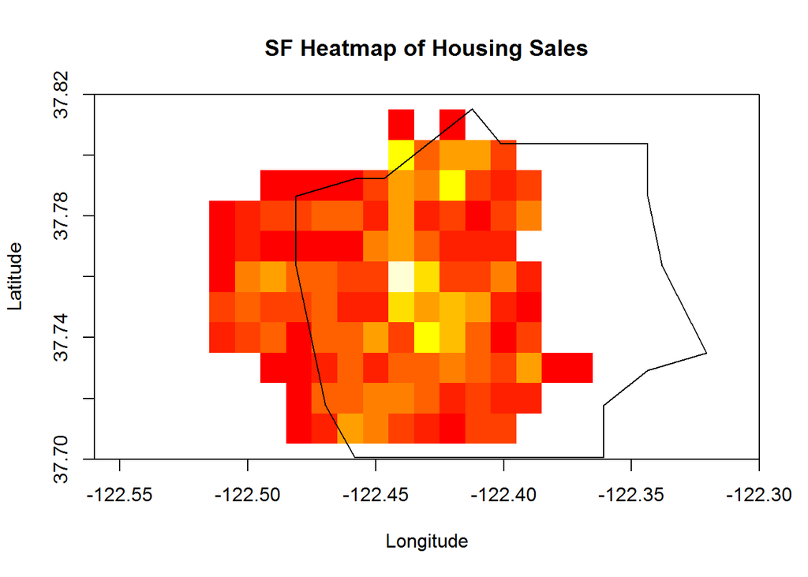